**Statistical Inference Course Project (Part 1)**

Note: Code for this document is available at https://github.com/robbinsr/siProjPart1.

**Instructions**

The exponential distribution can be simulated in R with rexp(n, lambda) where lambda is the rate parameter. The mean of exponential distribution is 1/lambda and the standard deviation is also also 1/lambda. Set lambda = 0.2 for all of the simulations. In this simulation, you will investigate the distribution of averages of 40 exponential(0.2)s. Note that you will need to do a thousand or so simulated averages of 40 exponentials.

Illustrate via simulation and associated explanatory text the properties of the distribution of the mean of 40 exponential(0.2)s. You should

1. Show where the distribution is centered at and compare it to the theoretical center of the distribution.
2. Show how variable it is and compare it to the theoretical variance of the distribution.
3. Show that the distribution is approximately normal.

Note that for point 3, focus on the difference between the distribution of a large collection of random exponentials and the distribution of a large collection of averages of 40 exponentials.

**Executive Summary**

Re: Point 1: This report shows that the distribution is centered at 5.0365828 and that the theory indicated it would be centered at 5. Re: Point 2: his report shows that distribution has a standard error of the mean of 0.7883693 and that the theory indicated it would be 0.7905694. Re: Point 3: This report shows that the distribution that was generated approximates the Gaussian distribution.

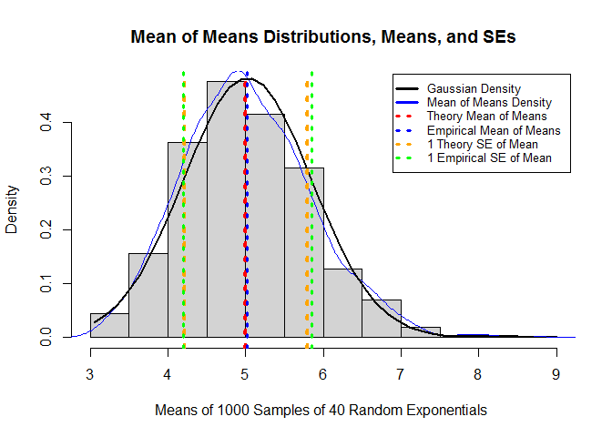

```
## [1] "#"
```

**Appendix**

Note that the results (as shown in the fitures) differ from since different simulations were run. The code for for the executive summary is hidden (i.e., echo=FALSE).

1. First I set the parameters as per the instructions and computed the expected, or theoretical mean (of the means of the samples that will be drawn) as well as the theoretical standard error.

```r
a_lambda <- 0.2
a_n=40
a_num_sims=1:1000
a_sample_mean<-1/lambda
a_SD<-1/a_lambda
a_exp_mean_of_means <- a_sample_mean
a_exp_SE_of_means <- SD / sqrt(n)
```

2. Then I checked to see that the function rexp() actually creates different distributions each time.

```r
par(mfrow = c(1,3))

set.seed(1020)
a_rexp_sim1<-rexp(a_n,a_lambda)
a_rexp_mean1<-round(mean(a_rexp_sim1),3)
a_rexp_sd1<-round(sd(a_rexp_sim1),3)
a_xname<-paste("Mean: ", a_rexp_mean1," SD: ", a_rexp_sd1)
hist(x=a_rexp_sim1,xlab=a_xname)

set.seed(3888)
a_rexp_sim2<-rexp(a_n,a_lambda)
a_rexp_mean2<-round(mean(a_rexp_sim2),3)
a_rexp_sd2<-round(sd(a_rexp_sim2),3)
a_xname<-paste("Mean: ", a_rexp_mean2," SD: ", a_rexp_sd2)
hist(x=a_rexp_sim2,xlab=a_xname)

set.seed(4242)
a_rexp_sim3<-rexp(a_n,a_lambda)
a_rexp_mean3<-round(mean(a_rexp_sim3),3)
a_rexp_sd3<-round(sd(a_rexp_sim3),3)
a_xname<-paste("Mean: ", a_rexp_mean3," SD: ", a_rexp_sd3)
hist(x=a_rexp_sim3,xlab=a_xname)
```

[output not shown]

3. Then I ran 1000 simulations of samples of 40 randomly drawn exponentials and computed the empirical mean as well as the empircal standard error.

```r
a_rexp_sims<-data.frame(lapply(a_num_sims, function (x) {rexp(a_n,a_lambda)}))
colnames(a_rexp_sims)<-a_num_sims
a_rexp_sims_sample_means<-data.frame(sapply(a_rexp_sims,mean))
colnames(a_rexp_sims_sample_means)<-c("means")
a_emp_mean_of_means<-mean(a_rexp_sims_sample_means[,1])
a_emp_SE_of_means<-sd(a_rexp_sims_sample_means[,1])
a_h<-unlist(a_rexp_sims_sample_means[,1])
```

4. Then I created a table and a histogram to show that the theory and the empirical results actually agreed.

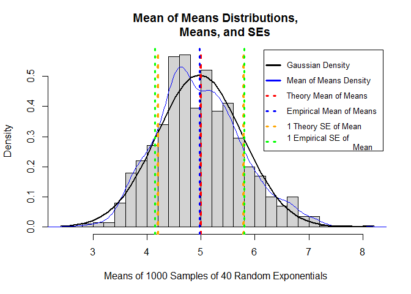

```r
statistics<-c(a_exp_mean_of_means,
              a_emp_mean_of_means,
              a_exp_SE_of_means,
              a_emp_SE_of_means)

a_t<-matrix(data=c(a_exp_mean_of_means,
                   a_emp_mean_of_means,a_exp_SE_of_means,a_emp_SE_of_means),
            nrow=2, ncol=2, byrow=TRUE)
a_t<-data.frame(a_t)
colnames(a_t)<-c("Theoretical","Empirical")
rownames(a_t)<-c("Mean","SE")

hist(a_h,breaks=20,col="light gray",prob=TRUE,main="Mean of Means Distributions,
     Means, and SEs",
     xlab="Means of 1000 Samples of 40 Random Exponentials ")
lines(density(a_h),col="blue")
legend("topright",legend=c("Gaussian Density", "Mean of Means Density",
                           "Theory Mean of Means",
                           "Empirical Mean of Means","1 Theory SE of Mean",
                           "1 Empirical SE of
                           Mean"),lty=c(1,1,3,3,3,3),lwd=c(3,3,3,3,3,3),
                            col=c("black","blue",
                           "red", "blue","orange","green"),
                            merge=TRUE,inset=.01,cex=.8,adj=0)

a_xfit<-seq(min(a_h),max(a_h),length=40)
    a_yfit<-dnorm(a_xfit,mean=mean(a_h),sd=sd(a_h))
lines(a_xfit, a_yfit, col="black", lwd=2)
abline(v=a_exp_mean_of_means,col="red", lwd=4, lty=3)
abline(v=a_emp_mean_of_means,col="blue", lwd=3, lty=3)
abline(v=a_exp_mean_of_means-exp_SE_of_means,col="orange", lwd=4, lty=3)
abline(v=a_exp_mean_of_means+exp_SE_of_means,col="orange", lwd=4, lty=3)
abline(v=a_emp_mean_of_means-emp_SE_of_means,col="green", lwd=3, lty=3)
abline(v=a_emp_mean_of_means+emp_SE_of_means,col="green", lwd=3, lty=3)
```

```r
a_t
```

```
##      Theoretical Empirical
## Mean   5.0000000 4.9751070
## SE     0.7905694 0.7900632
```